# Meeting 26-02-2018

```r
#Files
methods <-
  read.csv(
    "/home/r4ph/results/new/elasticsearch-hadoop/elasticsearch-hadoopall.csv",
    stringsAsFactors = FALSE
  )
```

### Changes Metrics With Method Rename Reffactoring

### Constraints:

- C1: Time series must have a minimum number of peaks to be considered (median of length of ts)
- C2: The time series of changes must not be constant.
- C3: This constraint defines that the time series of changes must be stationary
- C4: This constraint defines that the time series of bugs must be stationary.

##### Previous Results:

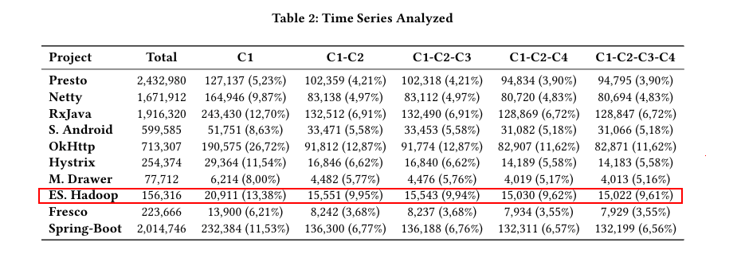

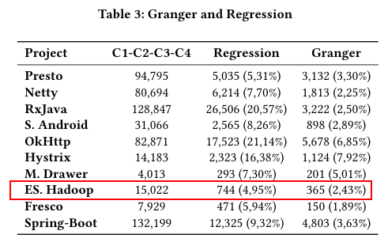

##### New Results:

```r
library(sqldf)
df <- sqldf(
  "SELECT Project, SUM(Count) as TotalTimeSeries,
   SUM(CASE WHEN (P1 = 1)  THEN 1 ELSE 0 end) as 'C1',
   SUM(CASE WHEN (P1 = 1) AND (P4 = 1) THEN 1 ELSE 0 end) as 'C1-C2',
   SUM(CASE WHEN (P1 = 1) AND (P4 = 1) AND (P5 = 1) THEN 1 ELSE 0 end) as 'C1-C2-C3',
   SUM(CASE WHEN (P1 = 1) AND (P4 = 1) AND (P3 = 1) THEN 1 ELSE 0 end) as 'C1-C2-C4',
   SUM(CASE WHEN (P1 = 1) AND (P4 = 1) AND (P3 = 1) AND (P5 = 1) THEN 1 ELSE 0 end) as 'C1-C2-C3-C4',
   SUM(CASE WHEN (GrangerPos = 1) THEN 1 ELSE 0 end) as GrangerPos
   FROM methods
   GROUP BY Project"
)
df
```

| Project | TotalTimeSeries | C1 | C1-C2 | C1-C2-C3 | C1-C2-C4 | C1-C2-C3-C4 | GrangerPos |
| --- | --- | --- | --- | --- | --- | --- | --- |
| elasticsearch-hadoop | 140303 | 25815 | 19190 | 0 | 1934 | 0 | 340 |

```r
library(dplyr)
getPosGranger <- function (x) {
  if (x <= 0.05 && x != -1) {
    1
  } else {
    0
  }
}
getSatisfiedTs <- function (x, measure) {
  print(measure)
  if (x >= measure) {
    1
  } else{
    0
  }
}
filenames=list.files(path= "/home/r4ph/R/analysis/software-metrics/", full.names=TRUE)
sm <- do.call(rbind, lapply(filenames, function(i) {
  read.csv(i, stringsAsFactors = FALSE)
}))
#Pos Grangers
sm[, "GrangerPos"] <- 0
sm$Granger[is.na(sm$Granger)] <- -1
sm$GrangerPos <- mapply(getPosGranger, sm$Granger)
sm[, "P1"] <- 0
#for (i in 1:length(unique(sm$Project))){
sm$P1 <- mapply(getSatisfiedTs, sm$lenghtTs, median(filter(sm, Project == sm$Project)$lenghtTs))
```

[output not shown]

[output cut: 46945 more lines]

### Analysis of Software Metrics:

- This table show the methods with positive granger by metrics.

```r
sm %>%
  group_by(Project, Metric) %>%
  summarise(GrangerPos = sum(GrangerPos))
```

| Project | Metric | GrangerPos |
| --- | --- | --- |
| Elasticsearch-hadoop | All | 0 |
| Elasticsearch-hadoop | CountInput | 379 |
| Elasticsearch-hadoop | CountLine | 472 |
| Elasticsearch-hadoop | CountLineBlank | 200 |
| Elasticsearch-hadoop | CountLineCode | 453 |
| Elasticsearch-hadoop | CountLineCodeDecl | 257 |
| Elasticsearch-hadoop | CountLineCodeExe | 437 |
| Elasticsearch-hadoop | CountLineComment | 156 |
| Elasticsearch-hadoop | CountOutput | 485 |
| Elasticsearch-hadoop | CountPath | 223 |

[output cut: 87 more lines]

### Constraints:

- C1: Time series musthave a minimum number of peaks to be considered (median of length of ts)
- C2: The time series of changes must not be constant.
- C3: This constraint defines that the time series of changes must be stationary
- C4: This constraint defines that the time series of bugs must be stationary.
- This table show the time series of projects along the constraints:

```r
library(sqldf)
sm[, "Count"] <- 1
dfsm <- sqldf(
  "SELECT Project, SUM(Count) as TotalTimeSeries,
   SUM(CASE WHEN (P1 = 1)  THEN 1 ELSE 0 end) as 'C1',
   SUM(CASE WHEN (P1 = 1) AND (P4 = 1) THEN 1 ELSE 0 end) as 'C1-C2',
   SUM(CASE WHEN (P1 = 1) AND (P4 = 1) AND (P5 = 1) THEN 1 ELSE 0 end) as 'C1-C2-C3',
   SUM(CASE WHEN (P1 = 1) AND (P4 = 1) AND (P3 = 1) THEN 1 ELSE 0 end) as 'C1-C2-C4',
   SUM(CASE WHEN (P1 = 1) AND (P4 = 1) AND (P3 = 1) AND (P5 = 1) THEN 1 ELSE 0 end) as 'C1-C2-C3-C4',
   SUM(CASE WHEN (P1 = 1) AND (P4 = 1) AND (P3 = 1) AND (P5 = 1) AND (GrangerPos = 1) THEN 1 ELSE 0 end) as 'C1-C4-Granger',
   SUM(CASE WHEN (GrangerPos = 1) THEN 1 ELSE 0 end) as 'Only-Granger'
   FROM sm
   GROUP BY Project"
)
dfsm$`Perc-C1-C4-Granger` <- round ((dfsm$`C1-C4-Granger`/dfsm$`C1-C2-C3-C4`) * 100, 2)
dfsm$`Perc-Only-Granger` <- round ((dfsm$`Only-Granger`/dfsm$TotalTimeSeries) * 100, 2)
dfsm <- dfsm[c(1:8, 10, 9, 11)]
dfsm
```

| Project | TotalTimeSeries | C1 | C1-C2 | C1-C2-C3 | C1-C2-C4 | C1-C2-C3-C4 | C1-C4-Granger | Perc-C1-C4-Granger | Only-Granger | Perc-Only-Granger |
| --- | --- | --- | --- | --- | --- | --- | --- | --- | --- | --- |
| Elasticsearch-hadoop | 65872 | 65872 | 6027 | 4635 | 5919 | 4527 | 1539 | 34.00 | 5850 | 8.88 |
| Fresco | 12190 | 0 | 0 | 0 | 0 | 0 | 0 | NaN | 1172 | 9.61 |
| Material Drawer | 9523 | 9523 | 1863 | 1431 | 1611 | 1179 | 282 | 23.92 | 825 | 8.66 |
| Presto | 53458 | 53458 | 3510 | 3384 | 3450 | 3336 | 837 | 25.09 | 2498 | 4.67 |
| RxJava | 701 | 701 | 0 | 0 | 0 | 0 | 0 | NaN | 0 | 0.00 |